# tmap

Author

Natalia Charzewska

# O dokumencie

Niniejszy dokument przedstawia podstawowe i najważniejsze informacje o pakiecie tmap.

Dokumentacja biblioteki została przygotowana zarówno z myślą o osobach rozpoczynających pracę z językiem R, jak i bardziej doświadczonych użytkownikach. Początkujący mogą korzystać ze szczegółowych opisów kolejnych funkcji oraz towarzyszących im przykładów i wizualizacji, które ułatwiają zrozumienie zmian wprowadzanych na mapie. Z kolei dla zaawansowanych użytkowników liczne ilustracje stanowią wygodny punkt odniesienia, umożliwiając szybkie odnalezienie poszukiwanych rozwiązań bez konieczności szczegółowego analizowania całej dokumentacji.

Dokument składa się z następujących części (wyróżnione sekcje różnią się od nazw rodziałów i podrozdziałów):

1. Wstęp (Instalacja i konfiguracja środowiska).
2. Minimalny kod potrzebny do stworzenia mapy oraz jego analiza.
3. Rozszerzenie kodu minalnego o argumenty funkcji i ich analiza (z przykładowymi mapami na końcu).
4. Przedstawienie kodu nie ograniczającego się do minimalnej ilości funkcji (z przykładowymi mapami na końcu).
5. Mapy interaktywne
6. Przykład wykorzystania z danymi biologicznymi.

# Biblioteka tmap - przegląd (cheatsheat)

Jednym z narzędzi umożliwiających pracę z danymi przestrzennymi w języku R jest biblioteka tmap. Została ona stworzona z myślą o wizualizacji danych geograficznych i kartograficznych, pozwalając na tworzenie zarówno statycznych, jak i interaktywnych map. Dzięki intuicyjnej składni oraz integracji z popularnymi formatami danych przestrzennych, tmap znajduje zastosowanie między innymi w ekologii, biogeografii i ochronie środowiska. Umożliwia ona przejrzyste przedstawianie rozmieszczenia gatunków, wyników analiz przestrzennych czy zależności między czynnikami środowiskowymi a badanymi organizmami, stanowiąc ważne uzupełnienie statystycznych możliwości języka R.

#### Instalacja pakietu

```r
#Instalacja pakietu tmap (wykonywane tylko jednokrotnie)
#install.packages("tmap")
```

#### Załadowanie pakietu

```r
library(tmap)
```

## Mapy tematyczne

Głównym przeznaczeniem biblioteki tmap jest tworzenie map tematycznych. Umożliwia ona wizualizację danych przestrzennych w formie map przedstawiających wybrane cechy, zjawiska lub zależności geograficzne, pełniąc funkcję analogiczną do tworzenia wykresów dla danych statystycznych.

### Kod minimalny - Podstawy

```r
#Wskazanie warstwy danych przestrzennych do wizualizacji
#(obiektu, który ma zostać zmapowany).
tm_shape(World) +
  #Określenie sposobu wyświetlania danych.
  #Funkcja tm_polygons() przedstawia obiekty w postaci wielokątów.
  tm_polygons()
```

```
[tip] Consider a suitable map projection, e.g. by adding `+ tm_crs("auto")`.
```

#### tm_shape()

`tm_shape()` - służy do wskazania obiektu przestrzennego, który ma zostać zwizualizowany. Innymi słowy, określa ona źródło danych przestrzennych wykorzystywane przez kolejne warstwy mapy. Funkcja ta stanowi pierwszy etap budowy mapy.

Sama funkcja nie generuje jeszcze żadnego widoku mapy. Jej zadaniem jest jedynie wskazanie, co ma zostać przedstawione, natomiast sposób wizualizacji zależy od kolejnych funkcji, które definiują wygląd i formę prezentacji danych.

#### Warstwy wizualizacji:

Aby utworzyć mapę, konieczne jest określenie sposobu prezentacji danych, czyli tego, w jaki sposób mają one zostać zobrazowane. Służą do tego funkcje warstwowe, które dobiera się w zależności od typu danych przestrzennych. Każda z nich odpowiada za inny sposób wizualizacji.

- `tm_polygons()` - wykorzystywana do wizualizacji obiektów poligonowych (np. granice państw, regiony)
- `tm_lines()` - stosowana dla danych liniowych (np. drogi, rzeki)
- `tm_dots()` oraz `tm_symbols()` - używane dla danych punktowych (`tm_symbols()` pozwala na bardziej złożoną symbolikę)
- `tm_raster()` - przeznaczona do danych rastrowych (np. modele wysokości terenu, dane satelitarne)

Przykładowe alternatywne wizualizacje zbioru danych World:

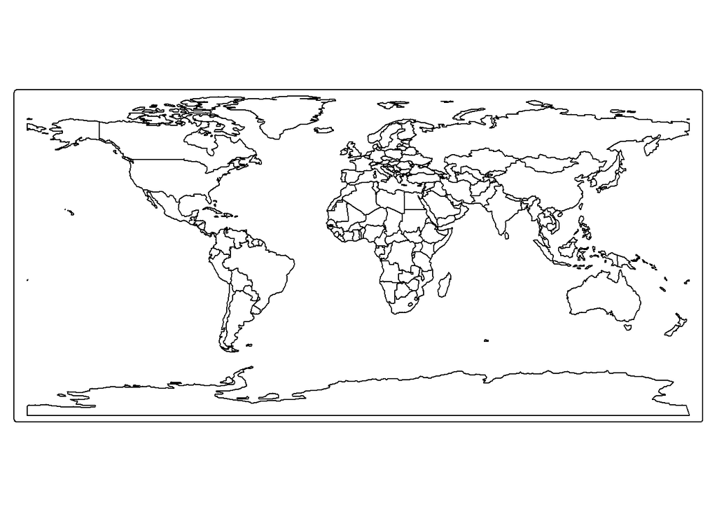

```r
#"World" jako zbiór linii
#(granice obiektów przestrzennych)
tm_shape(World) +
  tm_lines()
```

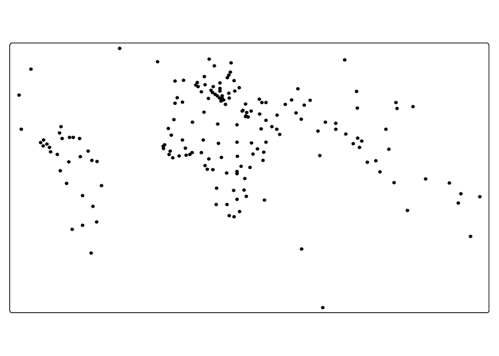

```r
#"World" jako zbiór punktów
#(geometryczne środki obiektów)
tm_shape(World) +
  tm_dots()
```

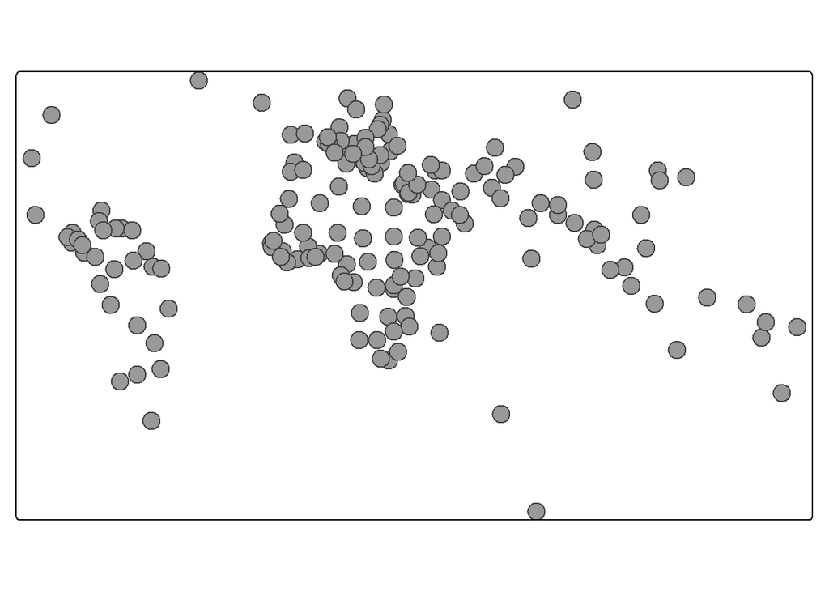

```r
#"World" jako zbiór symboli
tm_shape(World) +
  tm_symbols()
```

### Rozszerzenie kodu minimalnego

#### Przegląd dostępnych zbiorów danych :

```r
#Wyświetlenie listy zbiorów danych dostępnych w pakiecie tmap
data(package = "tmap")$results[, c("Item", "Title")]
```

```
     Item           Title
[1,] "NLD_dist"     "Netherlands datasets"
[2,] "NLD_muni"     "Netherlands datasets"
[3,] "NLD_prov"     "Netherlands datasets"
[4,] "World"        "World dataset"
[5,] "World_rivers" "Spatial data of rivers"
[6,] "land"         "Spatial data of global land cover"
[7,] "metro"        "Spatial data of metropolitan areas"
```

Przykłady wybranych zbiorów danych oraz odpowiednich warstw wizualizacji:

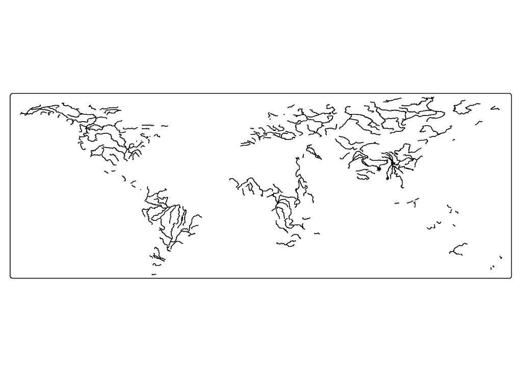

```r
#Rzeki świata
tm_shape(World_rivers) +
  tm_lines()
```

```
[scale] tm_raster:() the data variable assigned to 'col' contains positive and negative values, so midpoint is set to 0. Set 'midpoint = NA' in 'fill.scale = tm_scale_intervals(<HERE>)' to use all visual values (e.g. colors)
```

```
[plot mode] fit legend/component: Some legend items or map compoments do not
fit well, and are therefore rescaled.
ℹ Set the tmap option `component.autoscale = FALSE` to disable rescaling.
```

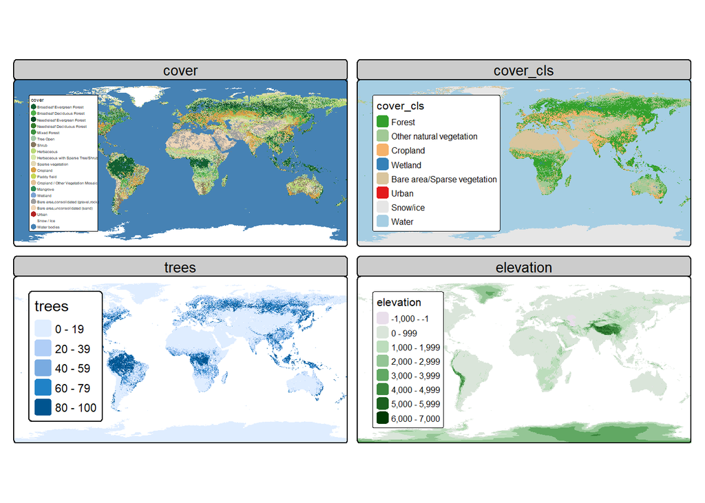

```r
#Raster "land" - wielowarstwowy zbiór danych opisujący cechy środowiska w przestrzeni
tm_shape(land) +
  tm_raster()
```

###### Przedstawienie pojedynczych struktur obiektu land:

```r
#Wypis dostępnych warstw danych
summary(land)
```

```
          Length Class  Mode
cover     583200 factor numeric
cover_cls 583200 factor numeric
trees     583200 -none- numeric
elevation 583200 -none- numeric
```

```
[plot mode] fit legend/component: Some legend items or map compoments do not
fit well, and are therefore rescaled.
ℹ Set the tmap option `component.autoscale = FALSE` to disable rescaling.
```

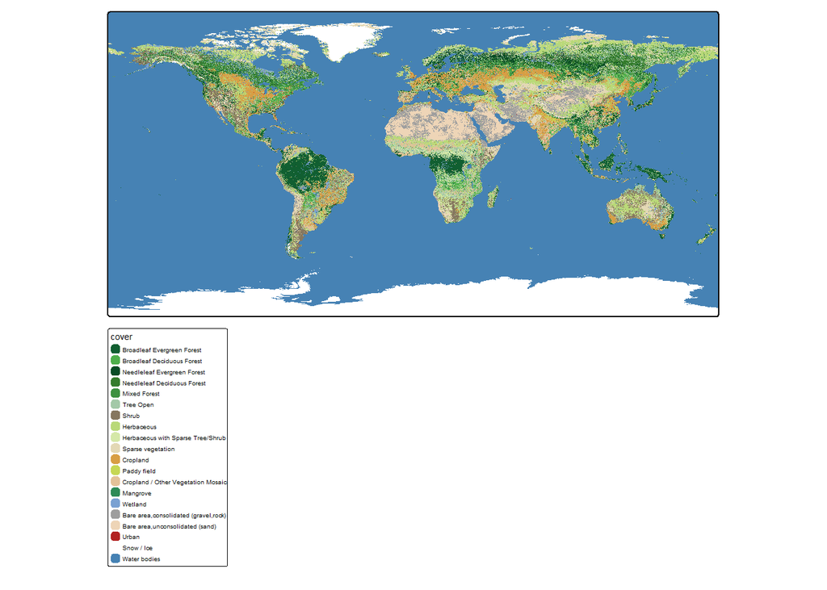

```r
#Tworzenie wizualizacji poszczególnych warstw rastera

#Pokrycie terenu
tm_shape(land["cover"]) +
  tm_raster()
```

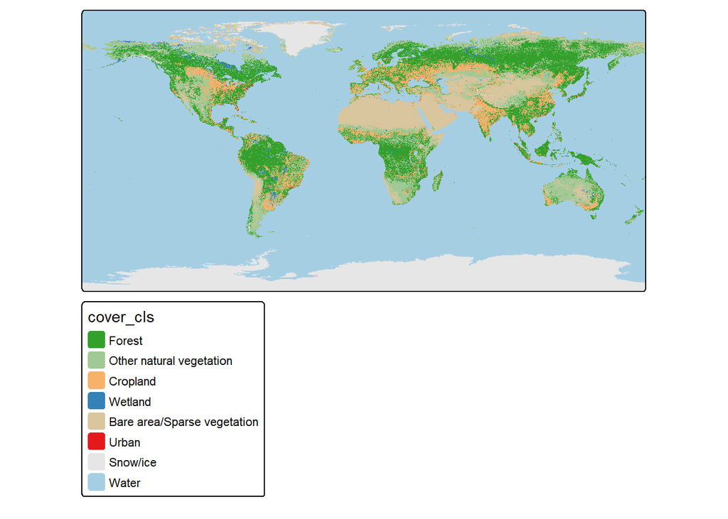

```r
#Uproszczena klasyfikacja pokrycia terenu
tm_shape(land["cover_cls"]) +
  tm_raster()
```

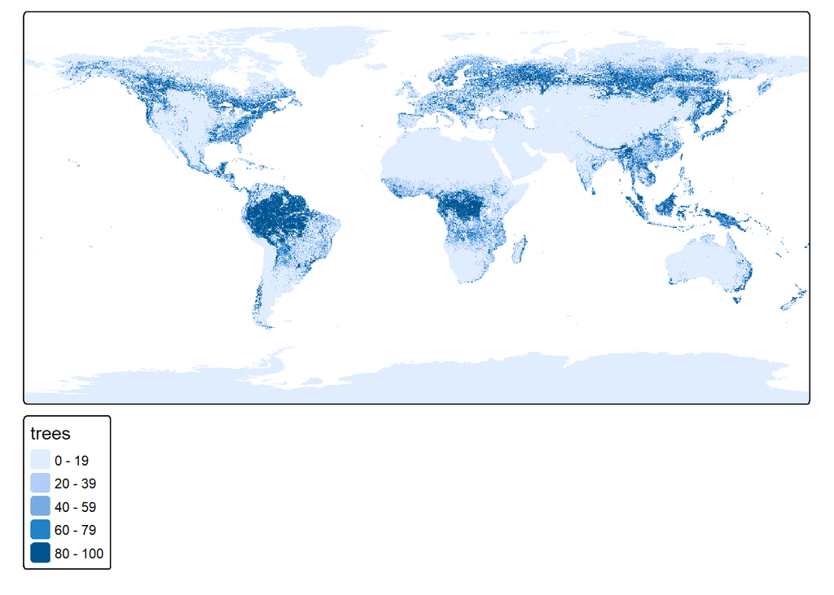

```r
#Procent pokrycia drzewostanem
tm_shape(land["trees"]) +
  tm_raster()
```

```
[scale] tm_raster:() the data variable assigned to 'col' contains positive and negative values, so midpoint is set to 0. Set 'midpoint = NA' in 'fill.scale = tm_scale_intervals(<HERE>)' to use all visual values (e.g. colors)
```

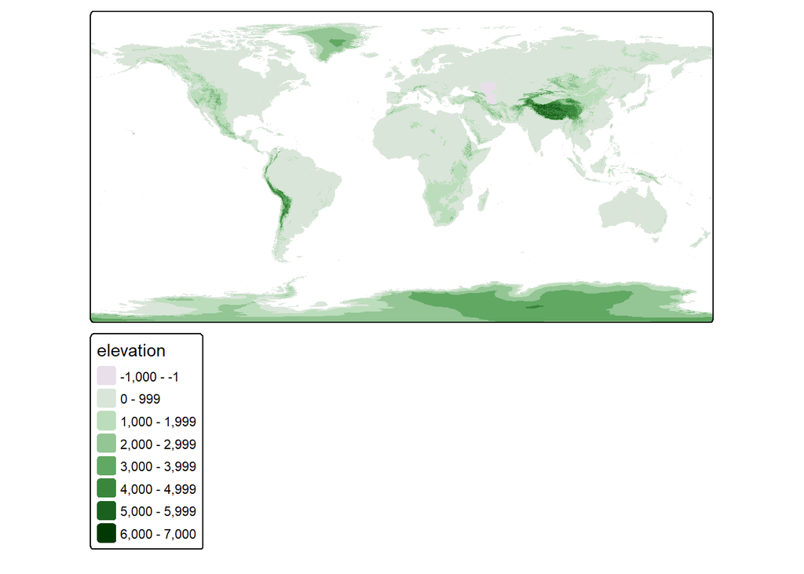

```r
#Wysokość n.p.m.
tm_shape(land["elevation"]) +
  tm_raster()
```

##### Wbudowane dane zbioru World:

Przykład dostępnych zmiennych (kolumn) w zbiorze danych World:

```r
names(World)
```

```
 [1] "iso_a3"       "name"         "sovereignt"   "continent"    "area"
 [6] "pop_est"      "pop_est_dens" "economy"      "income_grp"   "gdp_cap_est"
[11] "life_exp"     "well_being"   "footprint"    "HPI"          "inequality"
[16] "gender"       "press"        "geometry"
```

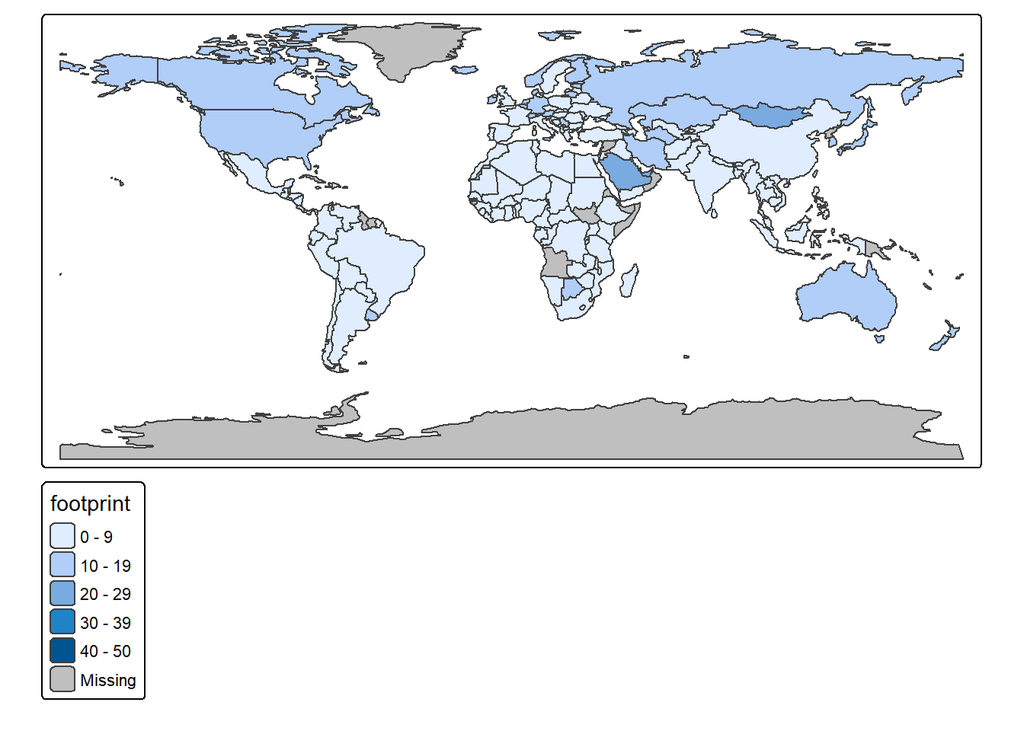

```r
#Podstawa mapy definiuje obiekt przestrzenny, który będzie wizualizowany
tm_shape(World) +
  #Wizualizacja danych z wykorzystaniem zmiennej footprint
  #Kolor mapy zależy od wartości footprint
  #ecological footprint - ślad ekologiczny, czyli szacunkowe zużycie zasobów Ziemi przypadające na mieszkańca danego kraju
  tm_polygons(fill = "footprint")
```

`fill = ...` - służy do określenia zmiennej, na podstawie której nadawane są kolory wypełnienia poligonów. Mogą to być zarówno zmienne ciągłe (liczbowe), jak i kategoryczne, w zależności od charakteru danych.

Podobną wizualizację można uzyskać również za pomocą funkcji plot(), jednak ma ona charakter bardziej poglądowy i oferuje ograniczone możliwości stylizacji w porównaniu do tmap. Funkcja ta jest szczególnie użyteczna przy szybkiej inspekcji danych, jednak mniej przydatna w przypadku tworzenia map publikacyjnych.

```r
#Wizualizacja danych zmiennej area z wykorzystaniem argumentu fill
tm_shape(World) +
  tm_polygons(fill = "area")
```

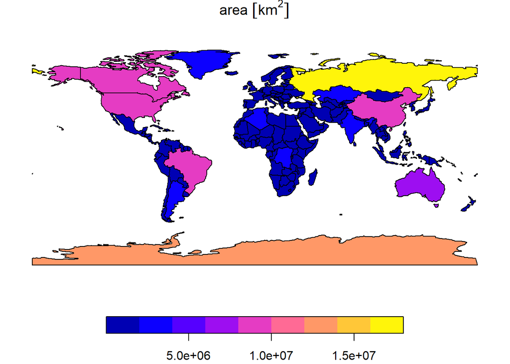

```r
#Wizualizacja danych zmiennej area z wykorzystaniem funkcji plot()
plot(World["area"])
```

#### tm_shape() - analiza argumentów

```r
#Wypis argumentów funckji tm_shape()
args(tm_shape)
```

```
function (shp = NULL, bbox = NULL, crs = NULL, is.main = NA,
    layer = NULL, name = NULL, unit = NULL, filter = NULL, ...)
NULL
```

Opis najważniejszych argumentów funckji tm_shape():

`shp` - obiekt przestrzenny (np. klasy sf, sp, raster), który ma zostać zwizualizowany. Argument ten może przyjmować różne typy danych przestrzennych, w tym obiekty wektorowe i rastrowe. Nazwa pochodzi od formatu shapefile, który historycznie był jednym z podstawowych formatów danych w systemach GIS (.shp).

```r
tm_shape(shp = World) +
  tm_polygons()
```

`bbox = c(xmin = ..., ymin = ..., xmax = ..., ymax = ...)` - (bounding box) określa ograniczenie przestrzenne mapy poprzez zdefiniowanie prostokątnego wycinka obszaru. Pozwala to na wyświetlenie jedynie wybranego fragmentu danych.

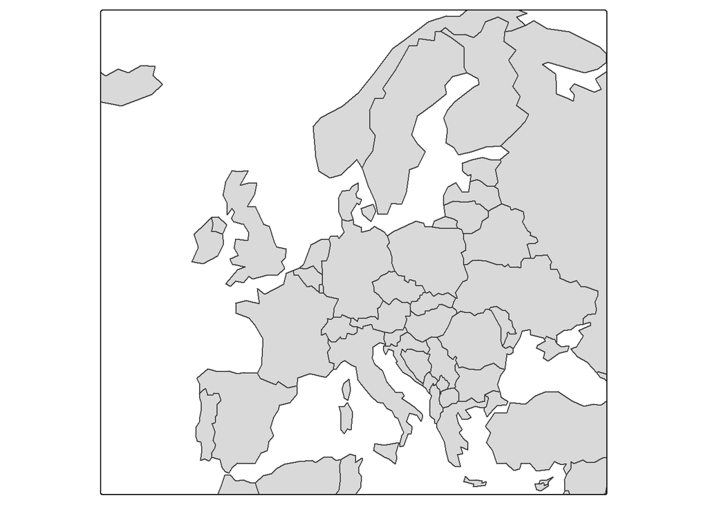

```r
#Europa (przybliżony zakres)
tm_shape(
  World,
  bbox = c(xmin = -20, ymin = 35, xmax = 40, ymax = 70)
) +
  tm_polygons()
```

`crs = ...` - (Coordinate Reference System) definiuje układ współrzędnych lub projekcję mapy. Zmiana tego parametru wpływa na sposób odwzorowania powierzchni Ziemi na płaszczyźnie, co może zmieniać wizualny kształt obiektów.

- EPSG:4326 - domyślny układ geograficzny (WGS84)
- +proj=robin - projekcja Robinsona (często używana w mapach świata)
- +proj=laea - projekcja azymutalna równopowierzchniowa

```r
# Domyślny układ współrzędnych (WGS84)
tm_shape(World, crs = "EPSG:4326") +
  tm_polygons()
```

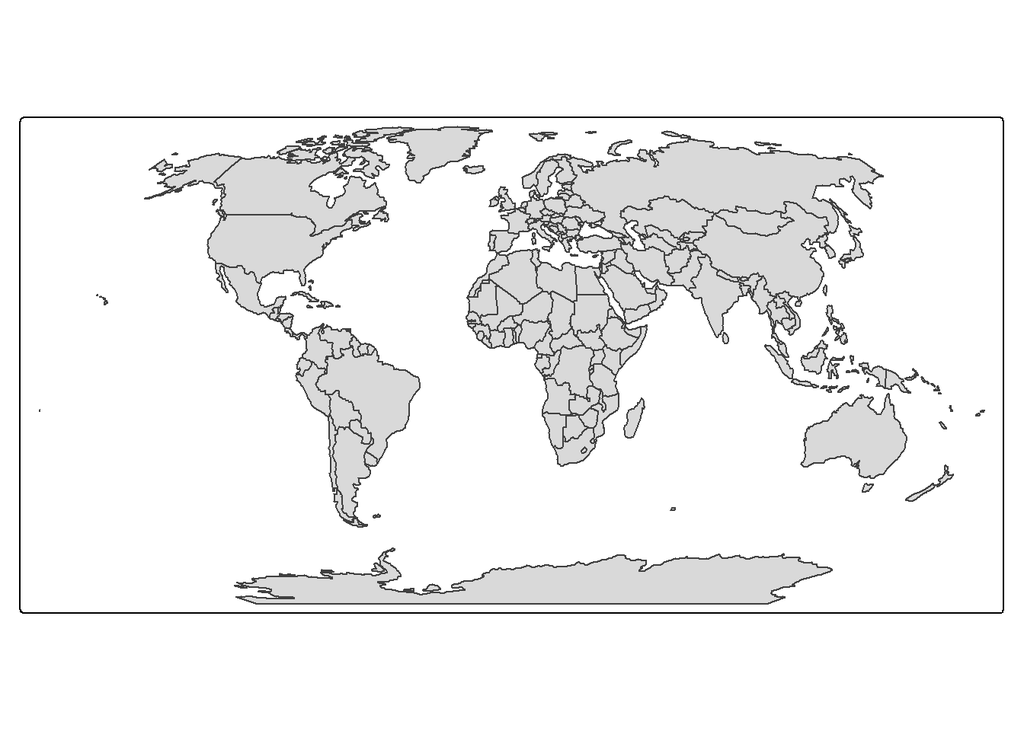

```r
# Projekcja Robinsona
tm_shape(World, crs = "+proj=robin") +
  tm_polygons()
```

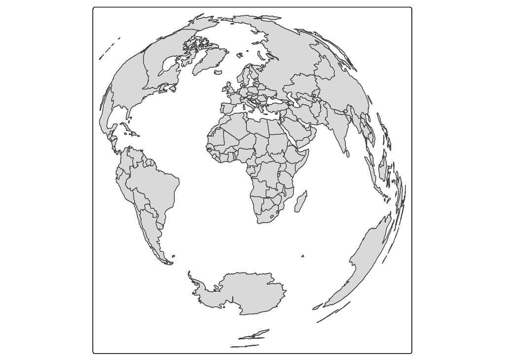

```r
# Projekcja azymutalna równopowierzchniowa
tm_shape(World, crs = "+proj=laea") +
  tm_polygons()
```

`name = "nazwa warstwy"` - określa nazwę warstwy, która może być wyświetlana w legendzie lub w trybie interaktywnym mapy.

`filter` - umożliwia filtrowanie danych przed ich wizualizacją, dzięki czemu na mapie pojawiają się tylko obiekty spełniające określony warunek.

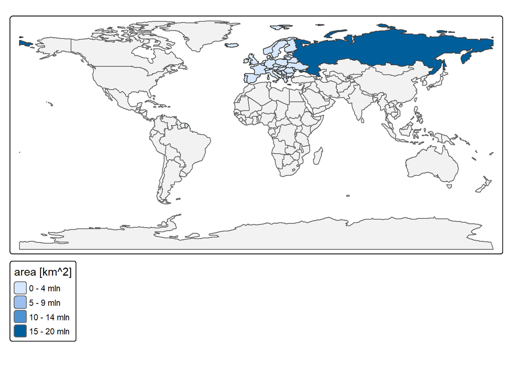

```r
tm_shape(
  World,
  filter = World$continent == "Europe"
) +
  tm_polygons(fill = "area")
```

#### tm_polygons - analiza funkcji tm_polygons

```r
#Wypis argumentów funckji tm_polygons()
args(tm_polygons)
```

```
function (fill = tm_const(), fill.scale = tm_scale(), fill.legend = tm_legend(),
    fill.chart = tm_chart_none(), fill.free = NA, col = tm_const(),
    col.scale = tm_scale(), col.legend = tm_legend(), col.chart = tm_chart_none(),
    col.free = NA, lwd = tm_const(), lwd.scale = tm_scale(),
    lwd.legend = tm_legend(), lwd.chart = tm_chart_none(), lwd.free = NA,
    lty = tm_const(), lty.scale = tm_scale(), lty.legend = tm_legend(),
    lty.chart = tm_chart_none(), lty.free = NA, fill_alpha = tm_const(),
    fill_alpha.scale = tm_scale(), fill_alpha.legend = tm_legend(),
    fill_alpha.chart = tm_chart_none(), fill_alpha.free = NA,
    col_alpha = tm_const(), col_alpha.scale = tm_scale(), col_alpha.legend = tm_legend(),
    col_alpha.chart = tm_chart_none(), col_alpha.free = NA, linejoin = "round",
    lineend = "round", plot.order = tm_plot_order("lwd", reverse = TRUE,
        na.order = "bottom"), zindex = NA, group = NA, group.control = "check",
    popup.vars = NA, popup.format = tm_label_format(), hover = NA,
    id = "", options = opt_tm_polygons(), ...)
NULL
```

Opis najważniejszych argumentów funckji tm_polygons():

`fill = ...` - określa sposób wypełnienia poligonów, czyli kolor ich wnętrza. Argument ten może przyjmować zarówno wartości stałe (np. nazwy kolorów), jak i nazwy zmiennych znajdujących się w zbiorze danych, na podstawie których generowana jest mapa tematyczna.

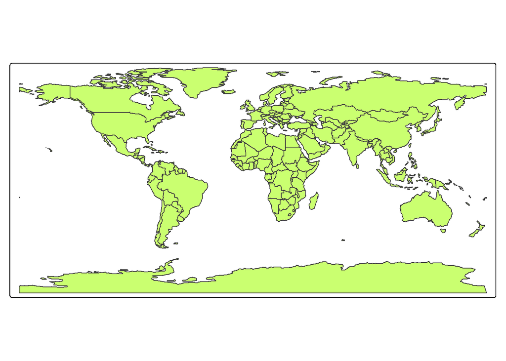

```r
#Kolorowanie stałą barwą
tm_shape(World) +
  tm_polygons(fill = "darkolivegreen1")
```

```r
#Kolorowanie na podstawie zmiennej (mapa tematyczna)
tm_shape(World) +
  tm_polygons(fill = "area")
```

`fill.scale = ...`- skala kolorów dla wypełnienia. Określa sposób odwzorowania wartości zmiennej na kolory.

- Definiowanie palety kolorów - `(tm_scale(values = ...))`

Argument values określa zestaw kolorów użytych do budowy skali.

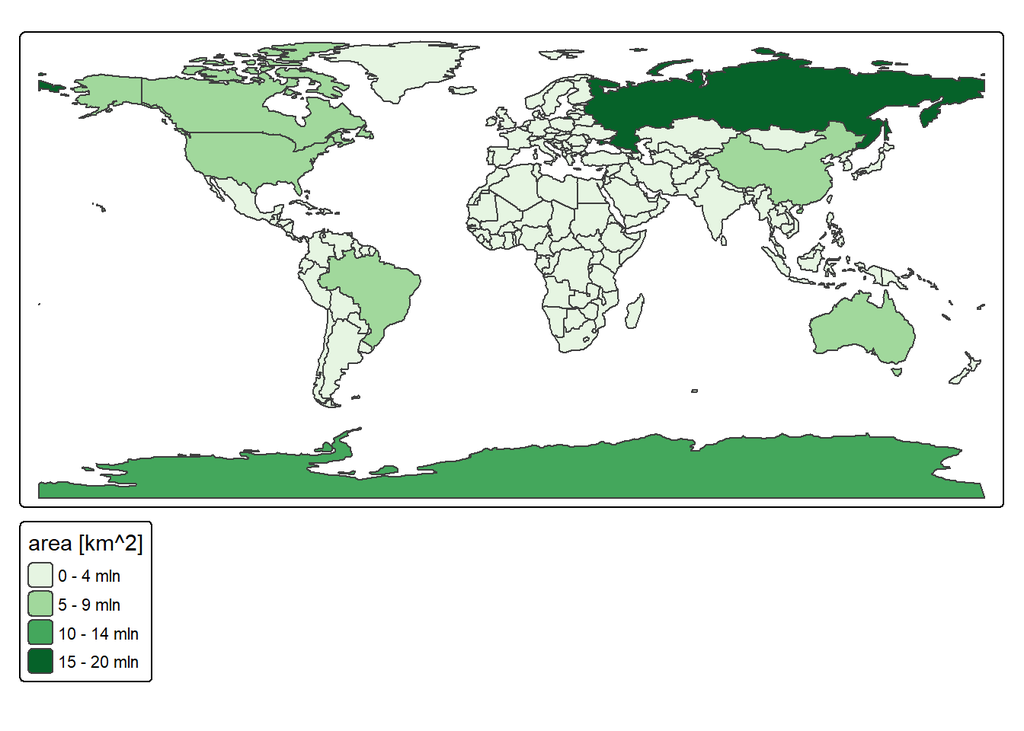

```r
tm_shape(World) +
  tm_polygons(
    fill = "area",
    #Wybór predefiniowanej palety kolorów
    fill.scale = tm_scale(values = "matplotlib.greens")
  )
```

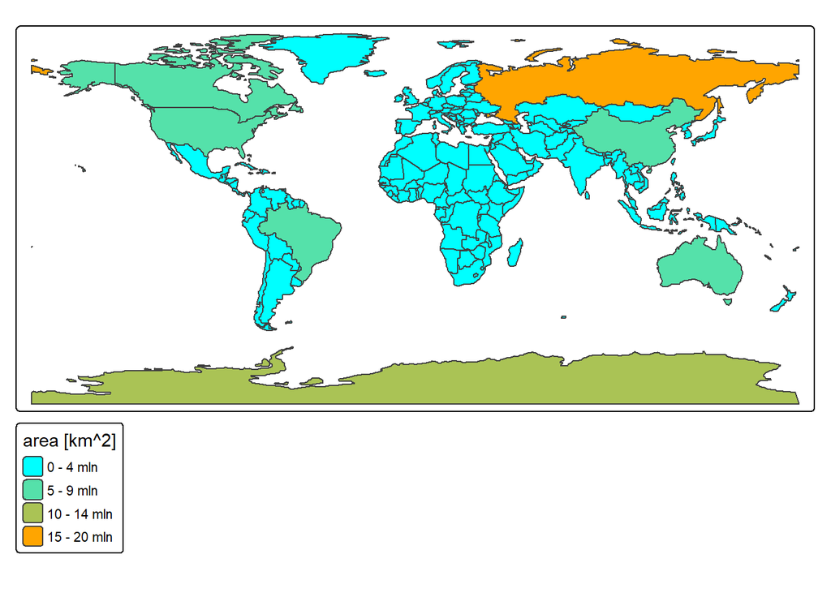

```r
tm_shape(World) +
  tm_polygons(
    fill = "area",
    #Własna paleta kolorów
    fill.scale = tm_scale(values = c("cyan", "orange"))
  )
```

- Podział danych na klasy - `(tm_scale_intervals())`

  Funkcja `tm_scale_intervals()` pozwala na dyskretyzację danych ciągłych, czyli podział ich na przedziały.

  Argumenty:
  - `n = liczba` - definiuje liczbę klas.
  - `style = ...` - określa sposób klasyfikacji

    `Dostępne metody klasyfikacji:
    - “quantile” - równa liczba obserwacji w każdej klasie
    - “equal” - równe przedziały wartości
    - “pretty” - „czytelne” (zaokrąglone) granice klas
    - “jenks” - natural breaks (minimalizacja wariancji wewnątrz klas)
    - “sd” - klasy na podstawie odchylenia standardowego
    - “fixed” - ręcznie zdefiniowane przedziały

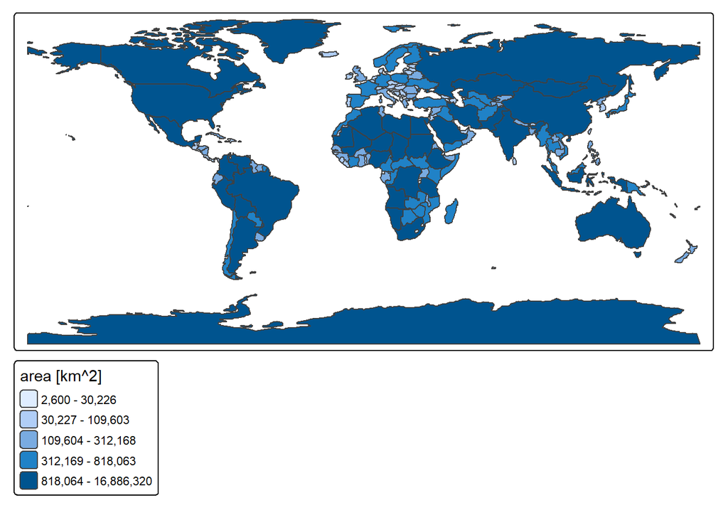

```r
tm_shape(World) +
  tm_polygons(
    fill = "area",
    fill.scale = tm_scale_intervals(
      n = 5,
      style = "quantile"
    )
  )
```

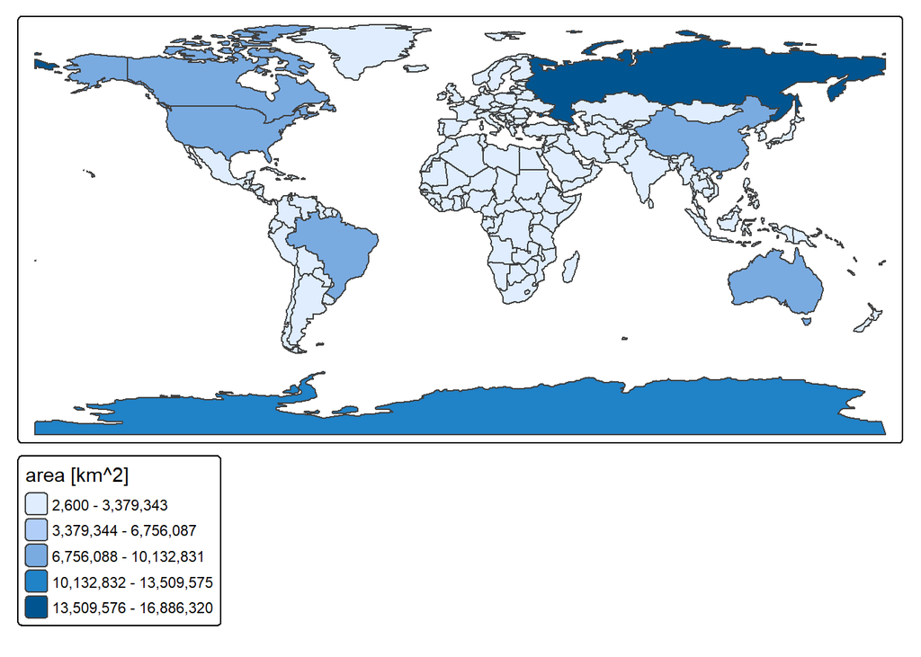

```r
tm_shape(World) +
  tm_polygons(
    fill = "area",
    fill.scale = tm_scale_intervals(
      n = 5,
      style = "equal"
    )
  )
```

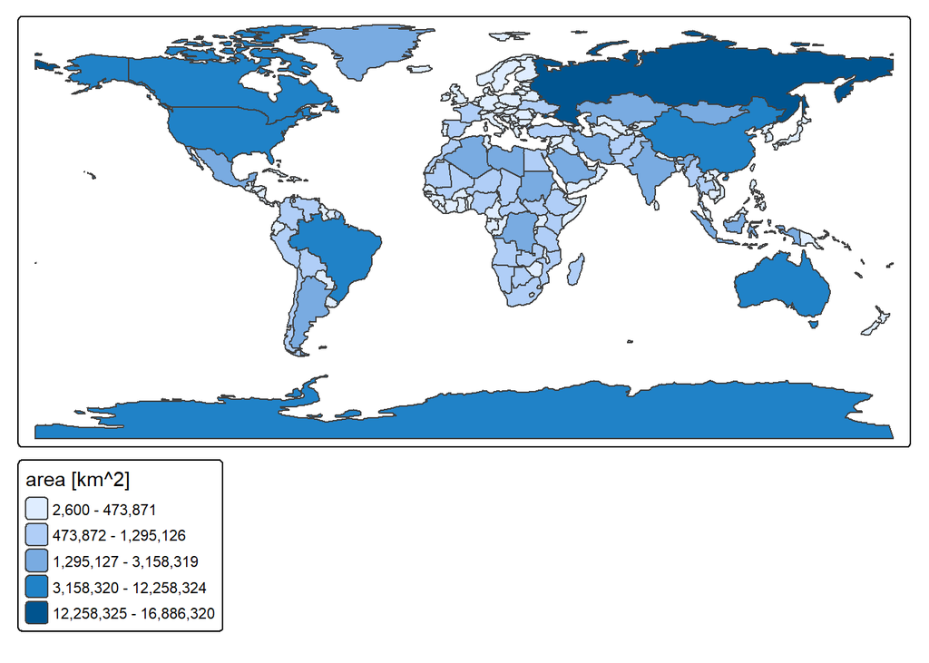

```r
tm_shape(World) +
  tm_polygons(
    fill = "area",
    fill.scale = tm_scale_intervals(
      n = 5,
      style = "jenks"
    )
  )
```

`fill.legend = ...` - służy do konfiguracji legendy odpowiadającej zmiennej użytej w argumencie fill. Pozwala na zmianę jej tytułu, zakresu, formatu opisu oraz sposobu prezentacji wartości w legendzie mapy.

Argumenty: - `title = ...` - ustawia tytuł legendy (opis wyświetlany na mapie) - `frame = ...` - określa, czy legenda ma mieć ramkę - `orientation = ...` - ustala orientację legendy - `reverse = ...` - odwraca kolejność wartości w legendzie

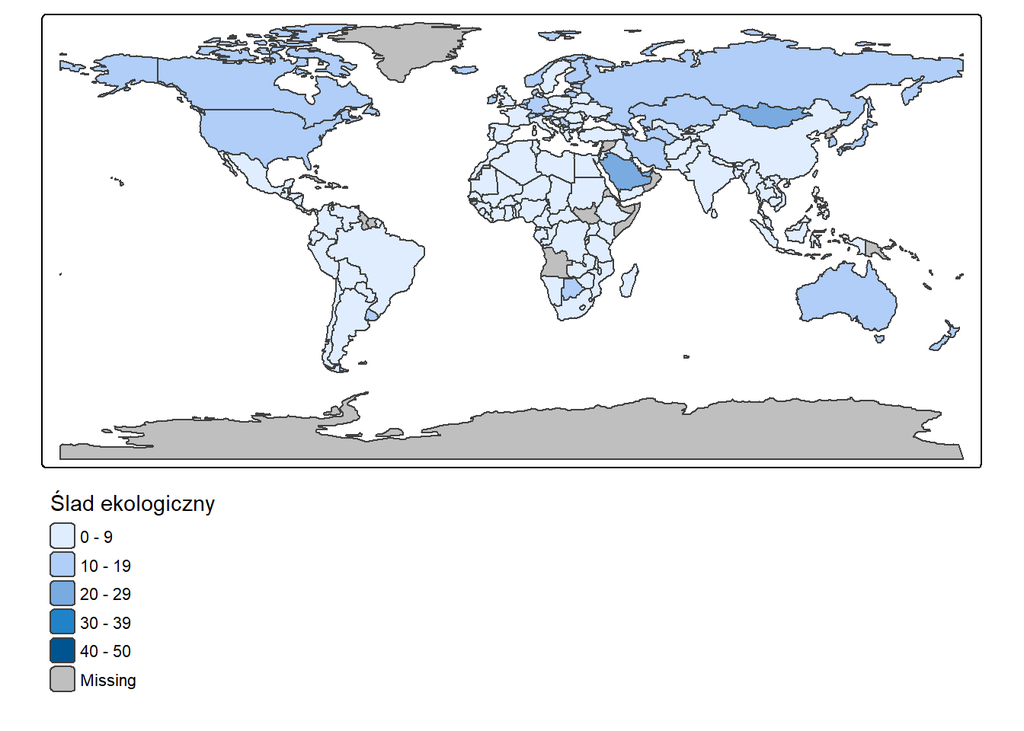

```r
#Wyłączenie ramki legendy + zmiana tytułu
tm_shape(World) +
  tm_polygons(
    fill = "footprint",
    fill.legend = tm_legend(
      title = "Ślad ekologiczny",
      frame = FALSE
    )
  )
```

`col = ...` - określa kolor obramowania (konturu) obiektów przestrzennych, w tym przypadku poligonów. Argument ten pozwala na zmianę barwy linii wyznaczających granice obiektów na mapie.

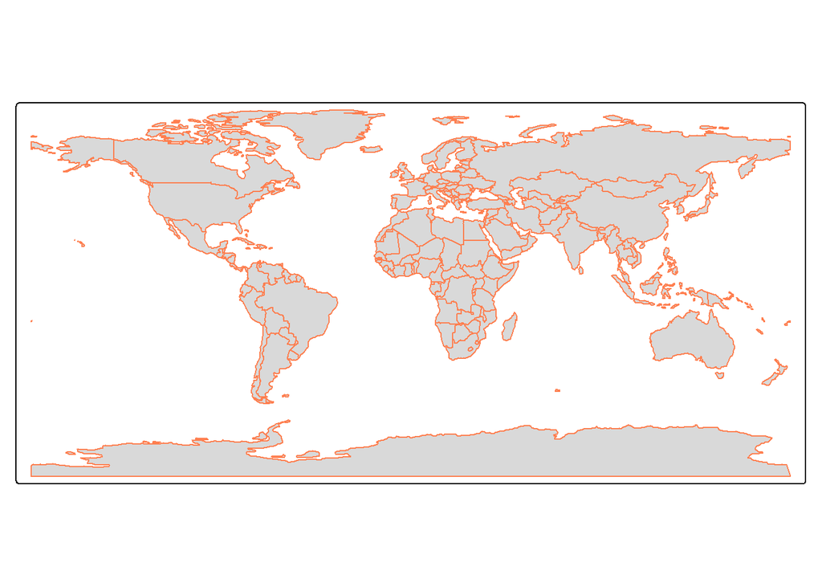

```r
#Ustawienie koloru obramowania poligonów
tm_shape(World) +
  tm_polygons(
    col = "coral"
  )
```

`lwd = liczba` - (line width) określa grubość linii obramowania obiektów przestrzennych. Wyższa wartość oznacza grubsze kontury granic.

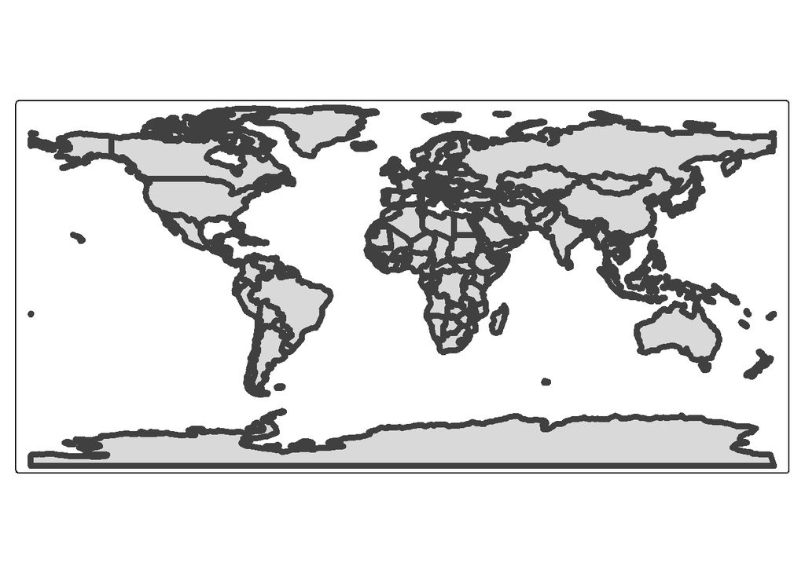

```r
tm_shape(World) +
  tm_polygons(lwd = 5)
```

`lty = ...` - (line type) określa styl linii obramowania (np. ciągła, przerywana, kropkowana).

```r
#domyślny styl (linia ciągła)
tm_shape(World) +
  tm_polygons(lty = "solid")
```

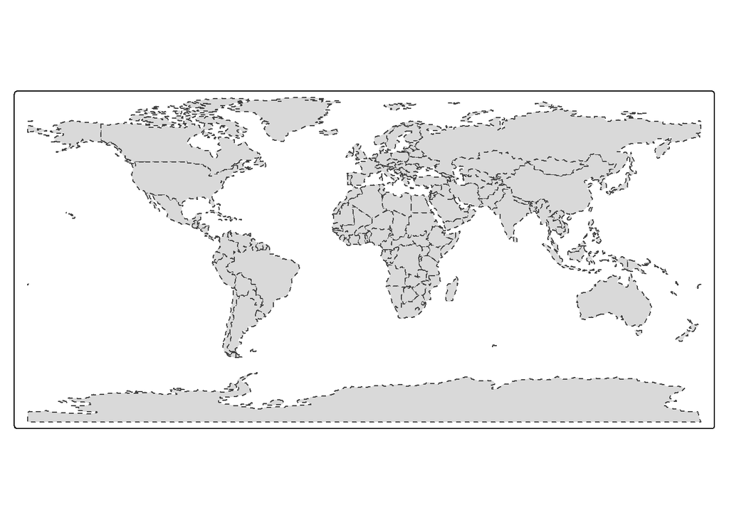

```r
#linia przerywana
tm_shape(World) +
  tm_polygons(lty = "dashed")
```

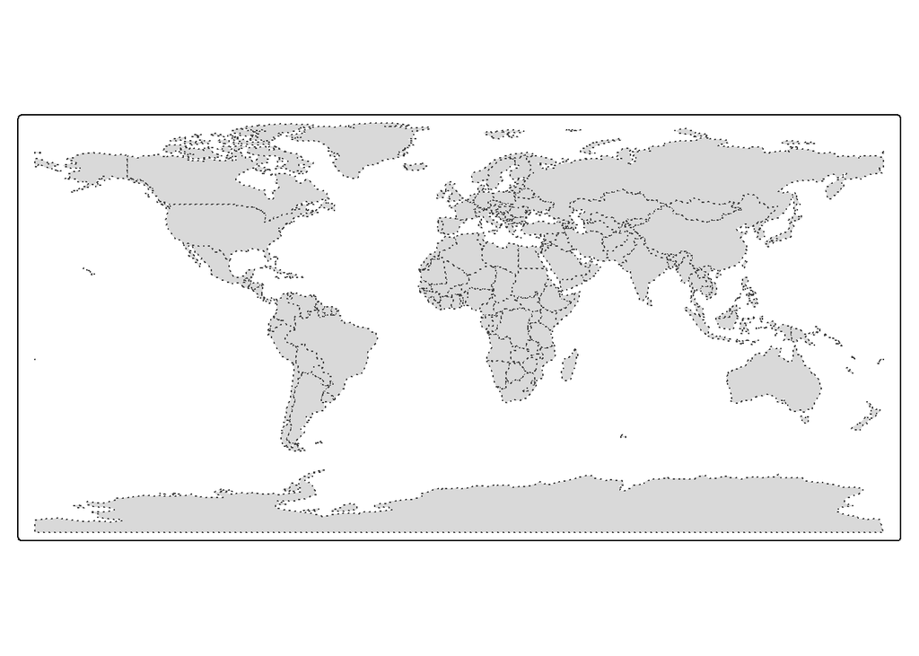

```r
#linia kropkowana
tm_shape(World) +
  tm_polygons(lty = "dotted")
```

`fill_alpha = liczba` - określa stopień przezroczystości wypełnienia poligonów. (Wartość mieści się w zakresie od 0 do 1.)

```r
#domyślna przezroczystość (brak przezroczystości)
tm_shape(World) +
  tm_polygons(fill = "area", fill_alpha = 1)
```

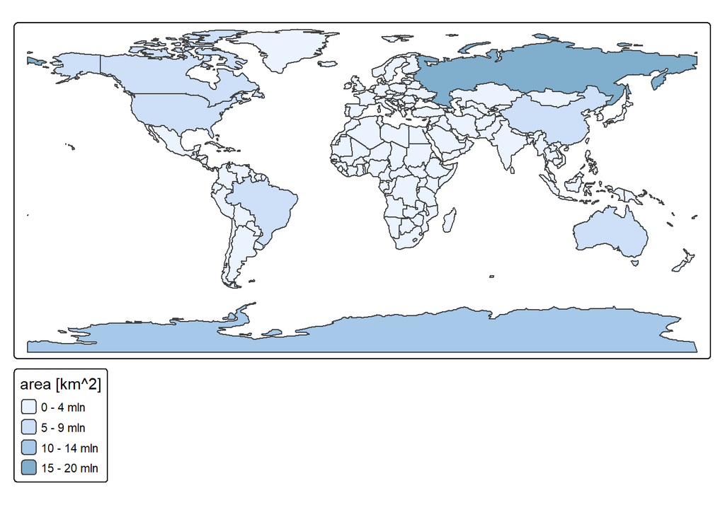

```r
#półprzezroczyste wypełnienie
tm_shape(World) +
  tm_polygons(fill = "area", fill_alpha = 0.5)
```

`col_alpha = liczba` - określa stopień przezroczystości obramowania (konturu) obiektów przestrzennych. (Wartość mieści się w zakresie od 0 do 1.)

```r
#domyślna przezroczystość - brak
tm_shape(World) +
  tm_polygons(col_alpha = 1)
```

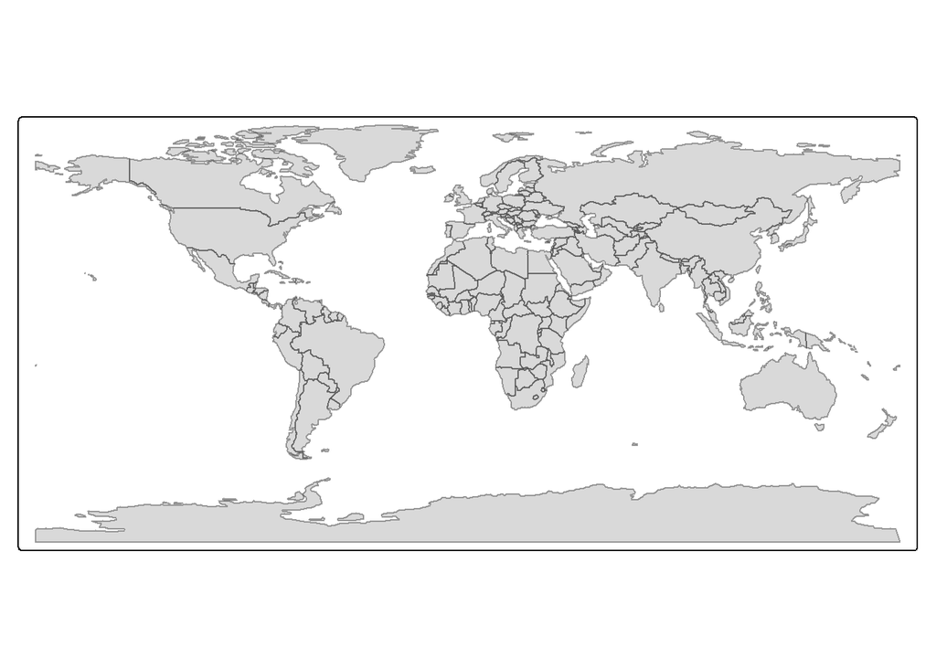

```r
#połowiczna przezroczystość
tm_shape(World) +
  tm_polygons(col_alpha = 0.5)
```

`plot.order` - określa kolejność rysowania obiektów na mapie. Ma znaczenie szczególnie w przypadku nakładających się warstw lub obiektów o różnych stylach (np. poligony z grubymi obramowaniami), ponieważ wpływa na to, które elementy są rysowane jako pierwsze, a które znajdują się na wierzchu.

`popup.vars` - Co robi? Dla map interaktywnych (view mode) — definiuje zmienne, które mają być wyświetlane w oknie podręcznym (popup) w trybie interaktywnym `(view mode)`. Pozwala określić, jakie informacje o obiekcie pojawią się po jego kliknięciu na mapie.

### Przykładowe mapy (z jedną warstwą)

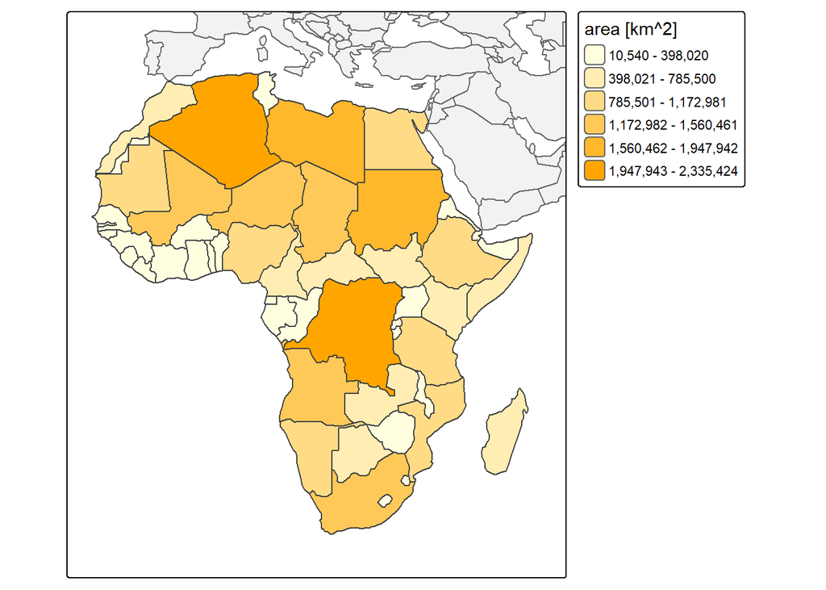

```r
tm_shape(
  World,
  #Układ współrzędnych (domyślny dla danych geograficznych)
  crs = "EPSG:4326",
  #Ograniczenie zakresu mapy do obszaru Afryki
  bbox = c(xmin = -20, ymin = -40, xmax = 55, ymax = 45),
  #Filtrowanie danych - wybór tylko kontynentu Afryka
  filter = World$continent == "Africa"
) +
  tm_polygons(
    fill = "area",
    fill.scale = tm_scale_intervals(
      n = 6,
      style = "equal",
      values = c("lightyellow", "orange")
    )
  )
```

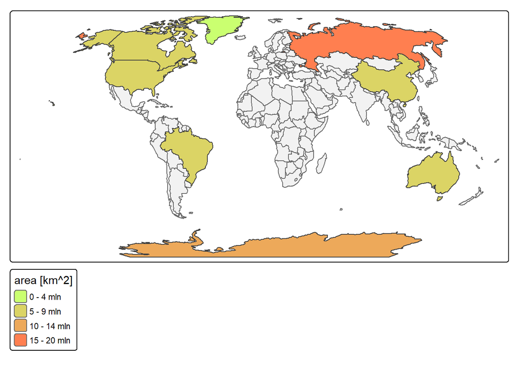

```r
tm_shape(
  World,
  crs = "+proj=robin",
  #Wybór wybranych państw na podstawie ich nazw.
    #Filtrowanie działa poprzez dopasowanie dokładnych wartości w kolumnie name
    #Błędy w nazwach (np. literówki) spowodują brak dopasowania obiektu.
      #Lista dostępnych państw: unique(World$name)
  filter = World$name %in% c(
    "Antarctica",
    "Australia",
    "Brazil",
    "Canada",
    "China",
    "Greenland",
    "Russia",
    "United States of America"
  )
) +
  tm_polygons(
    fill = "area",
    fill.scale = tm_scale(
      values = c("darkolivegreen1", "coral")
    )
  )
```

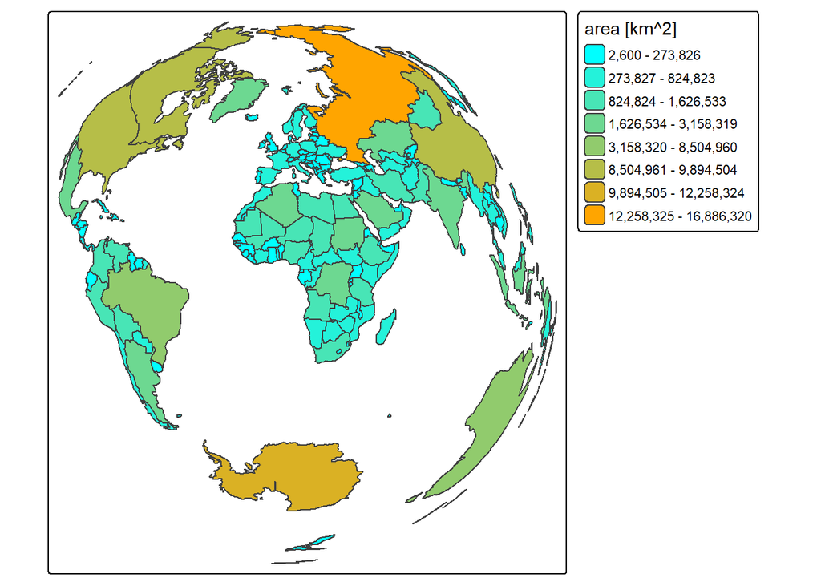

```r
tm_shape(World, crs = "+proj=laea") +
  tm_polygons(
    fill = "area",
    fill.scale = tm_scale_intervals(
      n = 8,
      style = "jenks",
      values = c("cyan", "orange")
    )
  )
```